# 3-layer-CNN

```python
import pandas as pd
import numpy as np
import matplotlib.pyplot as plt
import datetime as dt
from collections import UserDict
from glob import glob
from IPython.display import Image
%matplotlib inline
```

```python
df_store6 = pd.read_csv('store6eggs.csv')
df_store6.head()
```

|  | id | date | item_nbr | unit_sales | onpromotion | holiday_type | transferred | class | dcoilwtico |
| --- | --- | --- | --- | --- | --- | --- | --- | --- | --- |
| 0 | 6028 | 2013-01-02 | 127547 | 11.0 | True | Work Day | True | 2502 | 93.14 |
| 1 | 6045 | 2013-01-02 | 158680 | 3.0 | True | Work Day | True | 2502 | 93.14 |
| 2 | 6086 | 2013-01-02 | 208384 | 41.0 | True | Work Day | True | 2502 | 93.14 |
| 3 | 6087 | 2013-01-02 | 208386 | 13.0 | True | Work Day | True | 2502 | 93.14 |
| 4 | 6128 | 2013-01-02 | 227111 | 5.0 | True | Work Day | True | 2502 | 93.14 |

```python
df = df_store6[['date', 'unit_sales', 'holiday_type', 'transferred', 'dcoilwtico']]
df.head()
```

|  | date | unit_sales | holiday_type | transferred | dcoilwtico |
| --- | --- | --- | --- | --- | --- |
| 0 | 2013-01-02 | 11.0 | Work Day | True | 93.14 |
| 1 | 2013-01-02 | 3.0 | Work Day | True | 93.14 |
| 2 | 2013-01-02 | 41.0 | Work Day | True | 93.14 |
| 3 | 2013-01-02 | 13.0 | Work Day | True | 93.14 |
| 4 | 2013-01-02 | 5.0 | Work Day | True | 93.14 |

```python
df2 = df.groupby(['date', 'holiday_type', 'transferred', 'dcoilwtico']).sum().reset_index()
df2 = df2.rename(index = pd.to_datetime(df2['date']))
df2 = df2.drop(columns='date')
df2['holiday_type'] = df2['holiday_type'].astype('category')
df2['transferred'] = df2['transferred'].astype('int')
df2.head()
```

|  | holiday_type | transferred | dcoilwtico | unit_sales |
| --- | --- | --- | --- | --- |
| 2013-01-02 | Work Day | 1 | 93.14 | 360.0 |
| 2013-01-03 | Work Day | 1 | 92.97 | 253.0 |
| 2013-01-04 | Work Day | 1 | 93.12 | 204.0 |
| 2013-01-05 | Work Day | 0 | 93.12 | 259.0 |
| 2013-01-06 | Work Day | 1 | 93.12 | 445.0 |

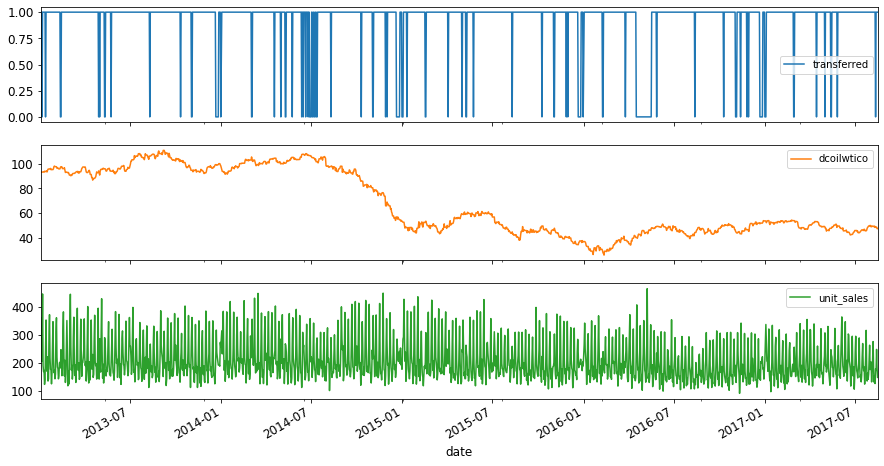

```python
df2.plot(y=['transferred', 'dcoilwtico', 'unit_sales'], subplots=True, figsize=(15, 8), fontsize=12)
plt.xlabel('date', fontsize=12)
plt.show()
```

```python
valid_start_dt = '2016-07-01'
test_start_dt = '2017-01-01'
```

```python
T = 7
HORIZON = 1
```

Our data preparation for the training set will involve the following steps:

1. Filter the original dataset to include only that time period reserved for the training set
2. Scale the time series such that the values fall within the interval (0, 1)
3. Shift the values of the time series to create a Pandas dataframe containing all the data for a single training example
4. Discard any samples with missing values
5. Transform this Pandas dataframe into a numpy array of shape (samples, features) for input into Keras

### 1. Filter the original dataset to include only that time period reserved for the training set

Create training set containing only the model features

```python
train = df2[df2.index < valid_start_dt]
from sklearn.preprocessing import MinMaxScaler
sales_scaler = MinMaxScaler()
oil_price_scaler = MinMaxScaler()
transferred_scaler = MinMaxScaler()
train['unit_sales'] = sales_scaler.fit_transform(pd.DataFrame(train['unit_sales']))
train['dcoilwtico'] = oil_price_scaler.fit_transform(pd.DataFrame(train['dcoilwtico']))
train['transferred'] = transferred_scaler.fit_transform(pd.DataFrame(train['transferred']))
train.head(10)
```

|  | holiday_type | transferred | dcoilwtico | unit_sales |
| --- | --- | --- | --- | --- |
| 2013-01-02 | Work Day | 1.0 | 0.792965 | 0.715847 |
| 2013-01-03 | Work Day | 1.0 | 0.790951 | 0.423497 |
| 2013-01-04 | Work Day | 1.0 | 0.792728 | 0.289617 |
| 2013-01-05 | Work Day | 0.0 | 0.792728 | 0.439891 |
| 2013-01-06 | Work Day | 1.0 | 0.792728 | 0.948087 |
| 2013-01-07 | Work Day | 1.0 | 0.793675 | 0.248634 |
| 2013-01-08 | Work Day | 1.0 | 0.793794 | 0.191257 |
| 2013-01-09 | Work Day | 1.0 | 0.792254 | 0.202186 |
| 2013-01-10 | Work Day | 1.0 | 0.800900 | 0.065574 |
| 2013-01-11 | Work Day | 1.0 | 0.798413 | 0.112022 |

### 3. Shift the values of the time series to create a Pandas dataframe containing all the data for a single training example

```python
train_shifted = train.copy()
train_shifted['y_t+1'] = train_shifted['unit_sales'].shift(-1)

for t in range(1, T+1):
    train_shifted['sales_t-'+str(T-t)] = train_shifted['unit_sales'].shift(T-t)

train_shifted['sales_t-30'] = train_shifted['unit_sales'].shift(30)
train_shifted['sales_t-90'] = train_shifted['unit_sales'].shift(90)
train_shifted['sales_t-365'] = train_shifted['unit_sales'].shift(365)
train_shifted = train_shifted.rename(columns={'unit_sales':'unit_sales_original'})
train_shifted['transferred_t+1'] = train_shifted['transferred'].shift(-1)

train_shifted.head(10)
```

[output not shown]

### 4. Discard any samples with missing values

```python
train_shifted = train_shifted.dropna(how='any')
train_shifted.head(5)
```

[output not shown]

### 5. Transform into a numpy arrays of shapes (samples, time steps, features) and (samples,1) for input into Keras

Now convert the target variable into a numpy array.

```python
y_train = train_shifted[['y_t+1']].as_matrix()

X_train = train_shifted.drop(['y_t+1', 'holiday_type', 'unit_sales_original'], axis = 1).as_matrix()
X_train = X_train[... , np.newaxis]
```

## Data preparation - validation set

```python
look_back_dt = pd.to_datetime(valid_start_dt) - dt.timedelta(days=T-1)
valid = df2[(df2.index >=look_back_dt) & (df2.index < test_start_dt)]
valid.head()
```

[output not shown]

```python
valid['unit_sales'] = sales_scaler.fit_transform(pd.DataFrame(valid['unit_sales']))
valid['dcoilwtico'] = oil_price_scaler.fit_transform(pd.DataFrame(valid['dcoilwtico']))
valid['transferred'] = transferred_scaler.fit_transform(pd.DataFrame(valid['transferred']))
valid.head(10)
```

[output not shown]

Prepare validation inputs in the same way as the training set:

```python
valid_shifted = valid.copy()
valid_shifted['y+1'] = valid_shifted['unit_sales'].shift(-1)
for t in range(1, T+1):
    valid_shifted['unit_sales_t-'+str(T-t)] = valid_shifted['unit_sales'].shift(T-t)
valid_shifted['oil_price_t-1'] = valid_shifted['dcoilwtico'].shift(1)
valid_shifted = valid_shifted.dropna(how='any')
y_valid = valid_shifted['y+1'].as_matrix()
X_valid = valid_shifted.drop(['y+1', 'unit_sales', 'holiday_type'], axis = 1).as_matrix()
X_valid = X_valid[..., np.newaxis]
```

## Implement the Convolutional Neural Network

```python
from tensorflow.keras.models import Model, Sequential
from tensorflow.keras.layers import Conv1D, Dense, Flatten, Activation
from tensorflow.keras.callbacks import EarlyStopping, ModelCheckpoint
```

```python
LATENT_DIM = 5
KERNEL_SIZE = 2
BATCH_SIZE = 32
EPOCHS = 10
```

```python
model = Sequential()
model.add(Conv1D(LATENT_DIM, kernel_size=KERNEL_SIZE, padding='causal', strides=1, activation='relu', dilation_rate=1, input_shape=(T+3, 1)))
model.add(Conv1D(LATENT_DIM, kernel_size=KERNEL_SIZE, padding='causal', strides=1, activation='relu', dilation_rate=2))
model.add(Conv1D(LATENT_DIM, kernel_size=KERNEL_SIZE, padding='causal', strides=1, activation='relu', dilation_rate=4))
model.add(Flatten())
model.add(Dense(HORIZON, activation='linear'))
```

Use Adam optimizer and mean squared error as the loss function.

```python
model.summary()
```

[output not shown]

```python
model.compile(optimizer='Adam', loss='mse')
```

#### Early stopping trick

Specify the early stopping criteria. We **monitor** the validation loss (in this case the mean squared error) on the validation set after each training epoch. If the validation loss has not improved by **min_delta** after **patience** epochs, we stop the training.

```python
earlystop = EarlyStopping(monitor='val_loss', min_delta=0, patience=5)
best_val = ModelCheckpoint('model_{epoch:02d}.h5', save_best_only=True, mode='min', period=1)
```

```
WARNING:tensorflow:`period` argument is deprecated. Please use `save_freq` to specify the frequency in number of samples seen.
```

```python
history = model.fit(X_train,
          y_train,
          batch_size=BATCH_SIZE,
          epochs=EPOCHS,
          validation_data=(X_valid, y_valid),
          callbacks=[earlystop, best_val],
          verbose=1)
```

```
Train on 1263 samples, validate on 182 samples
```

```python
best_epoch = np.argmin(np.array(history.history['val_loss']))+1
model.load_weights("model_{:02d}.h5".format(best_epoch))
```

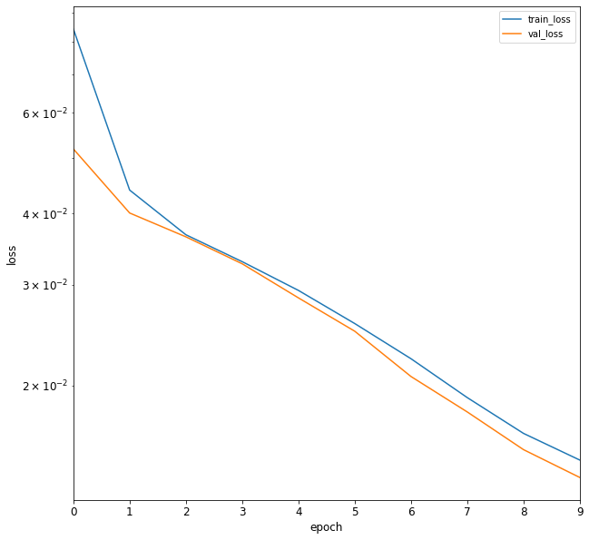

```python
plot_df = pd.DataFrame.from_dict({'train_loss':history.history['loss'], 'val_loss':history.history['val_loss']})
plot_df.plot(logy=True, figsize=(10,10), fontsize=12)
plt.xlabel('epoch', fontsize=12)
plt.ylabel('loss', fontsize=12)
plt.show()
```

## Evaluate the model

Create the test set

```python
look_back_dt = pd.to_datetime(test_start_dt) - dt.timedelta(days=T-1)
test = df2[test_start_dt:]

test['unit_sales'] = sales_scaler.fit_transform(pd.DataFrame(test['unit_sales']))
test['dcoilwtico'] = oil_price_scaler.fit_transform(pd.DataFrame(test['dcoilwtico']))
test['transferred'] = transferred_scaler.fit_transform(pd.DataFrame(test['transferred']))

test_shifted = test.copy()
test_shifted['y+1'] = test_shifted['unit_sales'].shift(-1)
for t in range(1, T+1):
    test_shifted['unit_sales_t-'+str(T-t)] = test_shifted['unit_sales'].shift(T-t)
test_shifted['oil_price_t-1'] = test_shifted['dcoilwtico'].shift(1)

test_shifted = test_shifted.dropna(how='any')
y_test = test_shifted['y+1'].as_matrix()
X_test = test_shifted.drop(['y+1', 'unit_sales', 'holiday_type'], axis = 1).as_matrix()
X_test = X_test[..., np.newaxis]
```

```python
predictions = model.predict(X_test)
predictions.shape
```

```
(216, 1)
```

```python
eval_df = pd.DataFrame(predictions, columns=['t+'+str(t) for t in range(1, HORIZON+1)])
eval_df['date'] = test_shifted.index
eval_df = pd.melt(eval_df, id_vars='date', value_name='prediction', var_name='d')
eval_df['actual'] = np.transpose(y_test).ravel()
eval_df[['prediction', 'actual']] = sales_scaler.inverse_transform(eval_df[['prediction', 'actual']])
eval_df.head()
```

|  | date | d | prediction | actual |
| --- | --- | --- | --- | --- |
| 0 | 2017-01-11 | t+1 | 157.404061 | 96.0 |
| 1 | 2017-01-12 | t+1 | 135.001916 | 162.0 |
| 2 | 2017-01-13 | t+1 | 205.085626 | 200.0 |
| 3 | 2017-01-14 | t+1 | 238.191608 | 333.0 |
| 4 | 2017-01-15 | t+1 | 187.816803 | 209.0 |

```python
def mape(predictions, actuals):
    return ((predictions - actuals).abs() / actuals).mean()
mape(eval_df['prediction'], eval_df['actual'])
```

```
0.14365855829736424
```